# 606_Week2Probability_Assignment

SantoshCheruku

February 12, 2019

####**2.6 Dice rolls. If you roll a pair of fair dice, what is the probability of**

```
Total probabilities - 6 X 6 -> 36
```

1. getting a sum of 1? **Answer: None**
2. getting a sum of 5? **Answer: 4/36 -> 1/9 ({1,4}, {4,1}, {2,3}, {3,2})**
3. getting a sum of 12? **Answer: 1/36 -> ({6,6})**

#### **2.8 Poverty and language. The American Community Survey is an ongoing survey that provides data every year to give communities the current information they need to plan investments and services. The 2010 American Community Survey estimates that 14.6% of Americans live below the poverty line, 20.7% speak a language other than English (foreign language) at home, and 4.2% fall into both categories**

P(A) - Probability of Americans below poverty lines - 14.6% => .146  
P(B) - Probability of American speaking foreign language - 20.7% => .207  
P(A) and P(B) - Probability of Americans below poverty line and speaking foreign language - 4.2% - .042

1. Are living below the poverty line and speaking a foreign language at home disjoint?

   Answer: No, because both these data can co exists.
2. Draw a Venn diagram summarizing the variables and their associated probabilities.

```r
library(VennDiagram)
```

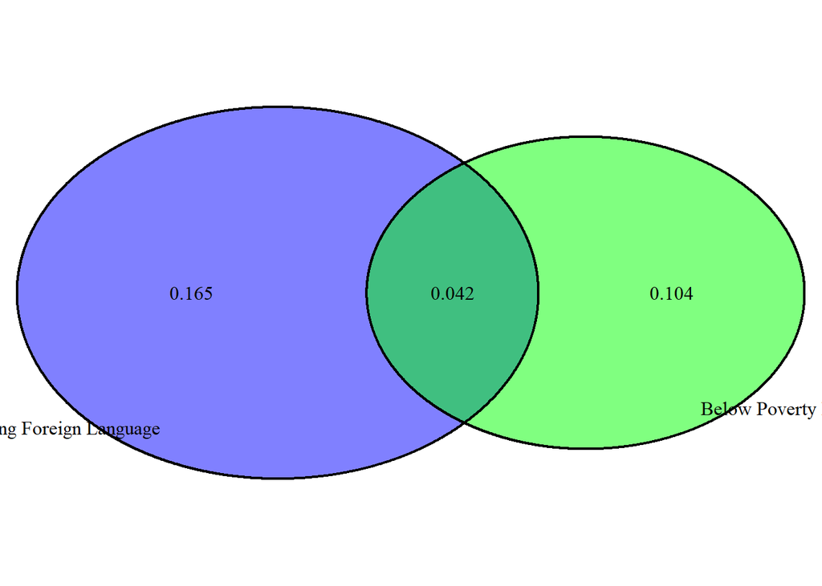

```
## (polygon[GRID.polygon.1], polygon[GRID.polygon.2], polygon[GRID.polygon.3], polygon[GRID.polygon.4], text[GRID.text.5], text[GRID.text.6], text[GRID.text.7], text[GRID.text.8], text[GRID.text.9])
```

```r
draw.pairwise.venn(area1 = 0.146, area2 = 0.207, cross.area = 0.042, category = c("Below Poverty Line", "Speaking Foreign Language"), fill = c("green","blue"))
```

3. What percent of Americans live below the poverty line and only speak English at home?

   Deducing from the above Venn diagram, the green only pie represents the above statement. Therefore, answer is .104 * 100 => 10.4%
4. What percent of Americans live below the poverty line or speak a foreign language at home?

```
P(A) = Probability of Male with blue eyes
P(B) = Probability of Female with blue eyes
P(C) = Probability of Male with brown eyes
P(G) = Probability of Male with green eyes
```

1. What is the probability that a randomly chosen male respondent or his partner has blue eyes?

   P(A ^ B) = P(A) + P(B) - P(A^B) = 108/204 + 114/204 - 78/204 = .70588
2. What is the probability that a randomly chosen male respondent with blue eyes has a partner with blue eyes?

   P(B|A) = P(B^A) / P(A) = 78 / 114 = .6842
3. What is the probability that a randomly chosen male respondent with brown eyes has a partner with blue eyes?

   P(B|C) = P(B^C) / P(C) = 19/54 = .3518

   c2: What about the probability of a randomly chosen male respondent with green eyes having a partner with blue eyes?

   P(B|G) = P(B^G) / P(G) = 11/36 = .305
4. Does it appear that the eye colors of male respondents and their partners are independent? Explain your reasoning.

1. Find the probability of drawing a hardcover book first then a paperback fiction book second when drawing without replacement.

   P(H).P(PF) = 28/95 * 59/94 = .1845
2. Determine the probability of drawing a fiction book first and then a hardcover book second, when drawing without replacement.

   P(F).P(H) = 72/95 * 28/94 = .2257
3. Calculate the probability of the scenario in part (b), except this time complete the calculations under the scenario where the first book is placed back on the bookcase before randomly drawing the second book.

   P(F).P(H) = 72/95 * 28/95 = .2233
4. The final answers to parts (b) and (c) are very similar. Explain why this is the case.

   They are almost similar since sample quantity is relatively higher, reducing the effect of replacement factor.

**2.38 Baggage fees. An airline charges the following baggage fees: $25 for the first bag and $35 for the second. Suppose 54% of passengers have no checked luggage, 34% have one piece of checked luggage and 12% have two pieces. We suppose a negligible portion of people check more than two bags.**

```
(a) Build a probability model, compute the average revenue per passenger, and compute the corresponding standard deviation.
```

```r
passenger_luggages_prob <- c(.54, .34, .12)
prices_luggages <- c(0, 25, 25+35)

#compute the average revenue per passenger
avg_revenue <- sum(passenger_luggages_prob * prices_luggages)

variance <- (0 - avg_revenue)^2 * passenger_luggages_prob[1] + (25 - avg_revenue)^2 * passenger_luggages_prob[2] + (60 - avg_revenue)^2 * passenger_luggages_prob[3]

variance
```

```
## [1] 398.01
```

```r
#compute the corresponding standard deviation
standard_dev <- sqrt(variance)

standard_dev
```

```
## [1] 19.95019
```

2. About how much revenue should the airline expect for a flight of 120 passengers? With what standard deviation? Note any assumptions you make and if you think they are justified.

```r
#Expected revenue for 120 passengers
revenue_120 <- avg_revenue * 120
revenue_120
```

```
## [1] 1884
```

```r
#Standard deviation
variance_120 <- variance * 120
sqrt(variance_120)
```

```
## [1] 218.5434
```

**2.44 Income and gender. The relative frequency table below displays the distribution of annual total personal income (in 2009 inflation-adjusted dollars) for a representative sample of 96,420,486 Americans. These data come from the American Community Survey for 2005-2009. This sample is comprised of 59% males and 41% females.**

[output not shown]

[figure not shown]

```
(b) What is the probability that a randomly chosen US resident makes less than $50,000 per year?
```

```r
income_brackets <- c("$1 to $9,999",  "$10,000 to $14,999", "$15,000 to $24,999", "$25,000 to $34,999", "$35,000 to $49,999", "$50,000 to $64,999", "$65,000 to $74,999", "$75,000 to $99,999", "$100,000 or more")
perc <- c(2.2, 4.7, 15.8, 18.3, 21.2, 13.9, 5.8, 8.4, 9.7)

barplot(perc, names.arg = income_brackets)
```

Sum of all probabilities for less than 50,000 => 2.2 + 4.7 + 15.8 + 18.3 + 21.2 = > 62.2/100 => .622

```
(c) What is the probability that a randomly chosen US resident makes less than $50,000 per year and is female?
    Note any assumptions you make.
```

Assuming income stats are independent of Male and Female. Probability of making less than 50K and probability of female => .622 * .41 => .25502

```
(d) The same data source indicates that 71.8% of females make less than $50,000 per year. Use this value to determine whether         or not the assumption you made in part (c) is valid.
```

This indicates that assumption made in c is not valid, since the probabilities vary indicating Female make less than Men.